# T2_Spotify (2)

**# As músicas mais transmitidas pelo Spotify em 2023.** ⏯

**Nome -** Edriene F. dos Santos Couto

Legenda dos dados

- **track_name:** Nome da música
- **artist(s)_name:** Nome do(s) artista(s) da música
- **artist_count:** número de artistas que contribuíram para a música
- **released_year:** Ano em que a música foi lançada
- **released_month:** Mês em que a música foi lançada
- **released_day:** Dia do mês em que a música foi lançada
- **in_spotify_playlists:** Número de playlists do Spotify nas quais a música está incluída
- **in_spotify_charts:** Presença e classificação da música nas paradas do Spotify
- **streams:** número total de streams no Spotify
- **in_apple_playlists:** número de playlists do Apple Music nas quais a música está incluída
- **in_apple_charts:** Presença e classificação da música nas paradas musicais da Apple
- **in_deezer_playlists:** Número de playlists do Deezer em que a música está incluída
- **in_deezer_charts:** Presença e posição da música nas paradas da Deezer
- **in_shazam_charts:** Presença e classificação da música nas paradas do Shazam
- **bpm:** Batidas por minuto, uma medida do andamento da música
- **key:** tom da música
- **mode:** Modo da música (maior ou menor)
- **danceability_%:** Porcentagem que indica quão adequada a música é para dançar
- **valence_%:** Positividade do conteúdo musical da música
- **energy_%:** Nível de energia percebido da música
- **acousticness_%:** quantidade de som acústico na música
- **instrumentalness_%:** Quantidade de conteúdo instrumental na música
- **liveness_%:** Presença de elementos de performance ao vivo
- **speechiness_%:** Quantidade de palavras faladas na música

```python
# Bibliotecas

import pandas as pd
import matplotlib.pyplot as plt
import numpy as np
import statsmodels.api as sm
import statistics
```

```python
#Dataset Spotify

spotify = pd.read_csv('spotify_songs.csv', encoding='ISO-8859-1')
spotify.head()
```

|  | track_name | artist(s)_name | artist_count | released_year | released_month | released_day | in_spotify_playlists | in_spotify_charts | streams | in_apple_playlists | ... | bpm | key | mode | danceability_% | valence_% | energy_% | acousticness_% | instrumentalness_% | liveness_% | speechiness_% |
| --- | --- | --- | --- | --- | --- | --- | --- | --- | --- | --- | --- | --- | --- | --- | --- | --- | --- | --- | --- | --- | --- |
| 0 | Seven (feat. Latto) (Explicit Ver.) | Latto, Jung Kook | 2 | 2023 | 7 | 14 | 553 | 147 | 141381703 | 43 | ... | 125 | B | Major | 80 | 89 | 83 | 31 | 0 | 8 | 4 |
| 1 | LALA | Myke Towers | 1 | 2023 | 3 | 23 | 1474 | 48 | 133716286 | 48 | ... | 92 | C# | Major | 71 | 61 | 74 | 7 | 0 | 10 | 4 |
| 2 | vampire | Olivia Rodrigo | 1 | 2023 | 6 | 30 | 1397 | 113 | 140003974 | 94 | ... | 138 | F | Major | 51 | 32 | 53 | 17 | 0 | 31 | 6 |
| 3 | Cruel Summer | Taylor Swift | 1 | 2019 | 8 | 23 | 7858 | 100 | 800840817 | 116 | ... | 170 | A | Major | 55 | 58 | 72 | 11 | 0 | 11 | 15 |
| 4 | WHERE SHE GOES | Bad Bunny | 1 | 2023 | 5 | 18 | 3133 | 50 | 303236322 | 84 | ... | 144 | A | Minor | 65 | 23 | 80 | 14 | 63 | 11 | 6 |

5 rows × 24 columns

```python
# Qual a média da quantidade de conteudo instrumental nas músicas da Taylor Swift?

taylor_songs = spotify[spotify['artist(s)_name']== 'Taylor Swift']

media_instrumental_taylor = taylor_songs['instrumentalness_%'].mean()

print("A média de conteúdo instrumental nas músicas da Taylor Swift em % é", media_instrumental_taylor)
```

```
A média de conteúdo instrumental nas músicas da Taylor Swift em % é 0.6764705882352942
```

```python
# Qual a mediana do número total de streams para as músicas do Ed Sheeran?

ed_sheeran_songs = spotify[spotify['artist(s)_name']== 'Ed Sheeran']

streams_ed_sheeran = ed_sheeran_songs['streams']

mediana_streams_ed = streams_ed_sheeran.median()

print(" A mediana do número total de streams no Spotify para as músicas do Ed Sheeran é", mediana_streams_ed)
```

```
 A mediana do número total de streams no Spotify para as músicas do Ed Sheeran é 1555511105.0
```

```python
#Moda - ocorrencia mais frequente no conjunto de dados analisados

# Qual é a música que aparece com mais frequência?

contagem_track_name = spotify['track_name'].value_counts()

#música com o maior indice de ocorrência
maisComum_track_name = contagem_track_name.idxmax()

print("Música mais comum em relação ao seu nome é", maisComum_track_name)
```

```
Música mais comum em relação ao seu nome é Daylight
```

```python
# Qual é a dispersão das classificações das músicas nas paradas do Spotify?

spotify_charts = spotify['in_spotify_charts']

#calculo do desvio
desvio_spotify = np.std(spotify_charts)

print("Desvio padrão das classificações nas paradas do Spotify é" , desvio_spotify)
```

```
Desvio padrão das classificações nas paradas do Spotify é 19.565718220687415
```

```python
"""Há diferença nas streams do Spotify entre músicas que aparecem  nas paradas da
Apple Music e as que aparecem nas da Deezer"""

#Converter a coluna analisada em numeros
spotify['streams'] = pd.to_numeric(spotify['streams'],errors='coerce')


#Filtra as musicas de cada parada
apple_songs = spotify[spotify['in_apple_charts']== True]
deezer_songs = spotify[spotify['in_deezer_charts'] == True]

varianciaApple = statistics.variance(apple_songs['streams'])
print("A variância das streams na Apple Music é", varianciaApple)


varianciaDeezer = statistics.variance(deezer_songs['streams'])
print("A variância das streams na Deezer é", varianciaDeezer)
```

```
A variância das streams na Apple Music é 7.418952876572142e+16
A variância das streams na Deezer é 3.270764377578301e+17
```

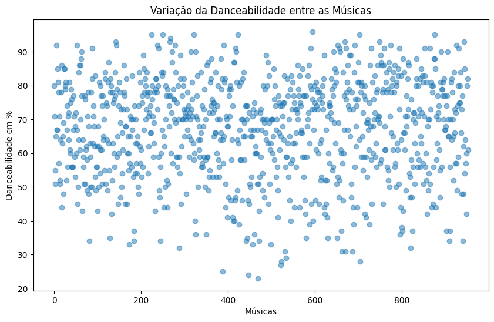

```python
# Qual a porcentagem que indica o quão dançável é a música?

musicaDancavel = spotify['danceability_%']


plt.figure(figsize=(10,6))
plt.scatter(range(len(musicaDancavel)), musicaDancavel, alpha=0.5)
plt.title('Variação da Danceabilidade entre as Músicas')
plt.xlabel('Músicas')
plt.ylabel('Danceabilidade em %')
plt.show()
```

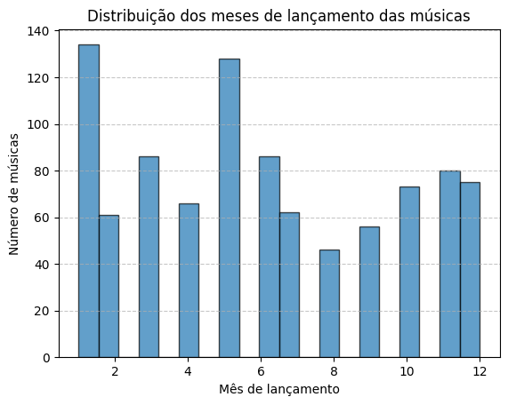

```python
# Qual a distribuição dos meses de lançamentos das músicas?

lancamentosMusica = spotify['released_month']

plt.hist(lancamentosMusica, bins = 20, edgecolor='k', alpha=0.7)
plt.title('Distribuição dos meses de lançamento das músicas')
plt.xlabel('Mês de lançamento')
plt.ylabel('Número de músicas')
plt.grid(axis='y', linestyle='--', alpha=0.7)
plt.show()
```

```python
"""Há uma relação entre o quão uma música é adequada para dançar e sua
positividade?"""

corrDV = np.corrcoef(spotify['danceability_%'], spotify['valence_%']) [0,1]
print("Correlação Dacenceabilidade-Valência é",corrDV)
```

```
Correlação Dacenceabilidade-Valência é 0.40845144016119944
```

```python
# As músicas mais rápidas têm uma energia percebida maior que as outras?

corrBPMEnergy = np.corrcoef(spotify['bpm'], spotify['energy_%']) [0,1]
print("Correlação BPM-Energia é",corrBPMEnergy)
```

```
Correlação BPM-Energia é 0.025794458095156677
```

```python
# Músicas mais dançáveis aparecem mais nas playlists do Spotify?

corrDancePlaylists = np.corrcoef(spotify['danceability_%'], spotify['in_spotify_playlists']) [0,1]
print("Correlação músicas dançáveis e visibilidade nas playlists é",corrDancePlaylists)
```

```
Correlação músicas dançáveis e visibilidade nas playlists é -0.10653367038753643
```

```python
"""Há uma correlação entre a quantidade de som acústico na música e a
quantidade de conteúdo instrumental?"""

corrAcousInstru = np.corrcoef(spotify['acousticness_%'], spotify['instrumentalness_%']) [0,1]
print("Correlação som acústico e instrumental é",corrAcousInstru)
```

```
Correlação som acústico e instrumental é 0.042795918372905
```

```python
# As músicas ao vivo tem mais visibilidade nas paradas do Spotify?

corrLiveSongs = np.corrcoef(spotify['liveness_%'], spotify['in_spotify_charts']) [0,1]
print("Correlação músicas ao vivo e visibilidade nas paradas é",corrLiveSongs)
```

```
Correlação músicas ao vivo e visibilidade nas paradas é -0.04755236634820553
```

```python
"""Existe uma relação que músicas dançáveis aparecem mais nas playlists do
Spotify do que as outras? Como podemos testar usando Regressão Linear?"""

#Correlação Fraca
danceability = spotify[['danceability_%']]
spotifyPlaylists = spotify[['in_spotify_playlists']]

#Constante para regressão
danceability = sm.add_constant(danceability)
danceability

#Modelo de regressão
modelo = sm.OLS(spotifyPlaylists, danceability).fit()
print(modelo.summary())
```

```
                             OLS Regression Results
================================================================================
Dep. Variable:     in_spotify_playlists   R-squared:                       0.011
Model:                              OLS   Adj. R-squared:                  0.010
Method:                   Least Squares   F-statistic:                     10.92
Date:                  Wed, 08 Nov 2023   Prob (F-statistic):           0.000988
Time:                          04:23:18   Log-Likelihood:                -9898.8
No. Observations:                   953   AIC:                         1.980e+04
Df Residuals:                       951   BIC:                         1.981e+04
Df Model:                             1
Covariance Type:              nonrobust
==================================================================================
                     coef    std err          t      P>|t|      [0.025      0.975]
----------------------------------------------------------------------------------
const           9051.3384   1193.042      7.587      0.000    6710.040    1.14e+04
danceability_%   -57.5069     17.405     -3.304      0.001     -91.663     -23.351
==============================================================================
Omnibus:                      602.941   Durbin-Watson:                   1.780
Prob(Omnibus):                  0.000   Jarque-Bera (JB):             5108.543
Skew:                           2.906   Prob(JB):                         0.00
Kurtosis:                      12.740   Cond. No.                         321.
==============================================================================

Notes:
[1] Standard Errors assume that the covariance matrix of the errors is correctly specified.
```

[figure not shown]

```python
#Gráfico Regressão Linear

previsao = modelo.predict()

plt.scatter(spotify['danceability_%'],
            spotify['in_spotify_playlists'], label="Dados")

plt.plot(spotify['danceability_%'], previsao, color='purple',
         linewidth=2, label='Regressão Linear')

plt.xlabel("Danceabilidade (%)")
plt.ylabel("Visibilidade nas Playlists")
plt.title("Danceabilidade X Visibilidade nas Playslists do Spotify")
plt.legend()
plt.show()
```

```python
"""Há uma relação entre o quão uma música é adequada para dançar
e sua positividade"""

danceability = spotify['danceability_%']
valencia = spotify['valence_%']

#Constante
danceability = sm.add_constant(danceability)
danceability

#Modelo de Regressão
modelo1 = sm.OLS(valencia,danceability).fit()
print(modelo1.summary())
```

```
                            OLS Regression Results
==============================================================================
Dep. Variable:              valence_%   R-squared:                       0.167
Model:                            OLS   Adj. R-squared:                  0.166
Method:                 Least Squares   F-statistic:                     190.4
Date:                Wed, 08 Nov 2023   Prob (F-statistic):           1.28e-39
Time:                        04:55:14   Log-Likelihood:                -4272.6
No. Observations:                 953   AIC:                             8549.
Df Residuals:                     951   BIC:                             8559.
Df Model:                           1
Covariance Type:            nonrobust
==================================================================================
                     coef    std err          t      P>|t|      [0.025      0.975]
----------------------------------------------------------------------------------
const              7.5312      3.256      2.313      0.021       1.141      13.921
danceability_%     0.6555      0.048     13.800      0.000       0.562       0.749
==============================================================================
Omnibus:                       30.290   Durbin-Watson:                   1.912
Prob(Omnibus):                  0.000   Jarque-Bera (JB):               14.554
Skew:                          -0.006   Prob(JB):                     0.000691
Kurtosis:                       2.395   Cond. No.                         321.
==============================================================================

Notes:
[1] Standard Errors assume that the covariance matrix of the errors is correctly specified.
```

[figure not shown]

```python
#Grafico de Regressão - Entidade Moderada

previsoes = modelo.predict()

plt.scatter(spotify['danceability_%'], spotify['valence_%'], label="Dados")

plt.plot(spotify['danceability_%'], previsoes, color = 'pink',
         linewidth=2, label="Regressão Linear")

plt.xlabel("Danceabilidade (%)")
plt.ylabel("Positividade (%)")
plt.title("Regressão Linear - Danceabilidade X Positividade")
plt.legend()
plt.show()
```

```python
#@title Convert ipynb to HTML in Colab
#Upload ipunb
from google.colab import files
f = files.upload()

#Convert ipynb to html
import subprocess
file0 = list(f.keys())[0]
_ = subprocess.run(["pip", "install", "nbconvert"])
_ = subprocess.run(["jupyter", "nbconvert", file0, "--to", "html"])

#dowload the html
files.download(file0[:-5]+"html")
```

Upload widget is only available when the cell has been executed in the current browser session. Please rerun this cell to enable.

```
Saving T2_Spotify.ipynb to T2_Spotify (1).ipynb
```